# Исследование объявлений о продаже квартир

В моем распоряжении объявления о продаже квартир в Санкт-Петербурге и Ленинградской области за несколько лет.

**Задача:** определить параметры которые влияют на рыночную стоимость объектов недвижимости

По каждой квартире на продажу доступны два вида данных. Первые вписаны пользователем, вторые — получены автоматически на основе картографических данных.

### Открою файл с данными и изучу общую информацию.

```python
import pandas as pd  #импортирую библиотеку pandas
import seaborn as sns #импортирую библиотеку seaborn
import matplotlib.pyplot as plt #импортирую библиотеку matplotlib.pyplot
```

```python
# использую try/except
try:
    data = pd.read_csv('/datasets/real_estate_data.csv', sep='\t') # читаю csv-файл, указываю разделитель '\t'
except:
    data = pd.read_csv('C:\\Users\\1\\Desktop\\учеба\\python\\Исследовательский анализ данных\\real_estate_data.csv', sep='\t')
```

```python
display(data.head(10))  # вывожу на экран первые 10 строк таблицы
```

|  | total_images | last_price | total_area | first_day_exposition | rooms | ceiling_height | floors_total | living_area | floor | is_apartment | ... | kitchen_area | balcony | locality_name | airports_nearest | cityCenters_nearest | parks_around3000 | parks_nearest | ponds_around3000 | ponds_nearest | days_exposition |
| --- | --- | --- | --- | --- | --- | --- | --- | --- | --- | --- | --- | --- | --- | --- | --- | --- | --- | --- | --- | --- | --- |
| 0 | 20 | 13000000.0 | 108.00 | 2019-03-07T00:00:00 | 3 | 2.70 | 16.0 | 51.00 | 8 | NaN | ... | 25.00 | NaN | Санкт-Петербург | 18863.0 | 16028.0 | 1.0 | 482.0 | 2.0 | 755.0 | NaN |
| 1 | 7 | 3350000.0 | 40.40 | 2018-12-04T00:00:00 | 1 | NaN | 11.0 | 18.60 | 1 | NaN | ... | 11.00 | 2.0 | посёлок Шушары | 12817.0 | 18603.0 | 0.0 | NaN | 0.0 | NaN | 81.0 |
| 2 | 10 | 5196000.0 | 56.00 | 2015-08-20T00:00:00 | 2 | NaN | 5.0 | 34.30 | 4 | NaN | ... | 8.30 | 0.0 | Санкт-Петербург | 21741.0 | 13933.0 | 1.0 | 90.0 | 2.0 | 574.0 | 558.0 |
| 3 | 0 | 64900000.0 | 159.00 | 2015-07-24T00:00:00 | 3 | NaN | 14.0 | NaN | 9 | NaN | ... | NaN | 0.0 | Санкт-Петербург | 28098.0 | 6800.0 | 2.0 | 84.0 | 3.0 | 234.0 | 424.0 |
| 4 | 2 | 10000000.0 | 100.00 | 2018-06-19T00:00:00 | 2 | 3.03 | 14.0 | 32.00 | 13 | NaN | ... | 41.00 | NaN | Санкт-Петербург | 31856.0 | 8098.0 | 2.0 | 112.0 | 1.0 | 48.0 | 121.0 |
| 5 | 10 | 2890000.0 | 30.40 | 2018-09-10T00:00:00 | 1 | NaN | 12.0 | 14.40 | 5 | NaN | ... | 9.10 | NaN | городской посёлок Янино-1 | NaN | NaN | NaN | NaN | NaN | NaN | 55.0 |
| 6 | 6 | 3700000.0 | 37.30 | 2017-11-02T00:00:00 | 1 | NaN | 26.0 | 10.60 | 6 | NaN | ... | 14.40 | 1.0 | посёлок Парголово | 52996.0 | 19143.0 | 0.0 | NaN | 0.0 | NaN | 155.0 |
| 7 | 5 | 7915000.0 | 71.60 | 2019-04-18T00:00:00 | 2 | NaN | 24.0 | NaN | 22 | NaN | ... | 18.90 | 2.0 | Санкт-Петербург | 23982.0 | 11634.0 | 0.0 | NaN | 0.0 | NaN | NaN |
| 8 | 20 | 2900000.0 | 33.16 | 2018-05-23T00:00:00 | 1 | NaN | 27.0 | 15.43 | 26 | NaN | ... | 8.81 | NaN | посёлок Мурино | NaN | NaN | NaN | NaN | NaN | NaN | 189.0 |
| 9 | 18 | 5400000.0 | 61.00 | 2017-02-26T00:00:00 | 3 | 2.50 | 9.0 | 43.60 | 7 | NaN | ... | 6.50 | 2.0 | Санкт-Петербург | 50898.0 | 15008.0 | 0.0 | NaN | 0.0 | NaN | 289.0 |

10 rows × 22 columns

При выводе на экран первых строк таблицы я вижу, что присутсвует множество пропущенных значений. Также бросается в глаза формат столбца `first_day_exposition`, его нужно будет привести к нормальному виду. Вывожу общую иформацию о таблице с помощью метода `info()`.

```python
data.info() #вывожу на экран общую информацию о таблице
```

```
<class 'pandas.core.frame.DataFrame'>
RangeIndex: 23699 entries, 0 to 23698
Data columns (total 22 columns):
 #   Column                Non-Null Count  Dtype
---  ------                --------------  -----
 0   total_images          23699 non-null  int64
 1   last_price            23699 non-null  float64
 2   total_area            23699 non-null  float64
 3   first_day_exposition  23699 non-null  object
 4   rooms                 23699 non-null  int64
 5   ceiling_height        14504 non-null  float64
 6   floors_total          23613 non-null  float64
 7   living_area           21796 non-null  float64
 8   floor                 23699 non-null  int64
 9   is_apartment          2775 non-null   object
 10  studio                23699 non-null  bool
 11  open_plan             23699 non-null  bool
 12  kitchen_area          21421 non-null  float64
 13  balcony               12180 non-null  float64
 14  locality_name         23650 non-null  object
 15  airports_nearest      18157 non-null  float64
 16  cityCenters_nearest   18180 non-null  float64
 17  parks_around3000      18181 non-null  float64
 18  parks_nearest         8079 non-null   float64
 19  ponds_around3000      18181 non-null  float64
 20  ponds_nearest         9110 non-null   float64
 21  days_exposition       20518 non-null  float64
dtypes: bool(2), float64(14), int64(3), object(3)
memory usage: 3.7+ MB
```

```python
print(data.isna().sum()) # выведу сумму пропусков по каждому столбцу
```

```
total_images                0
last_price                  0
total_area                  0
first_day_exposition        0
rooms                       0
ceiling_height           9195
floors_total               86
living_area              1903
floor                       0
is_apartment            20924
studio                      0
open_plan                   0
kitchen_area             2278
balcony                 11519
locality_name              49
airports_nearest         5542
cityCenters_nearest      5519
parks_around3000         5518
parks_nearest           15620
ponds_around3000         5518
ponds_nearest           14589
days_exposition          3181
dtype: int64
```

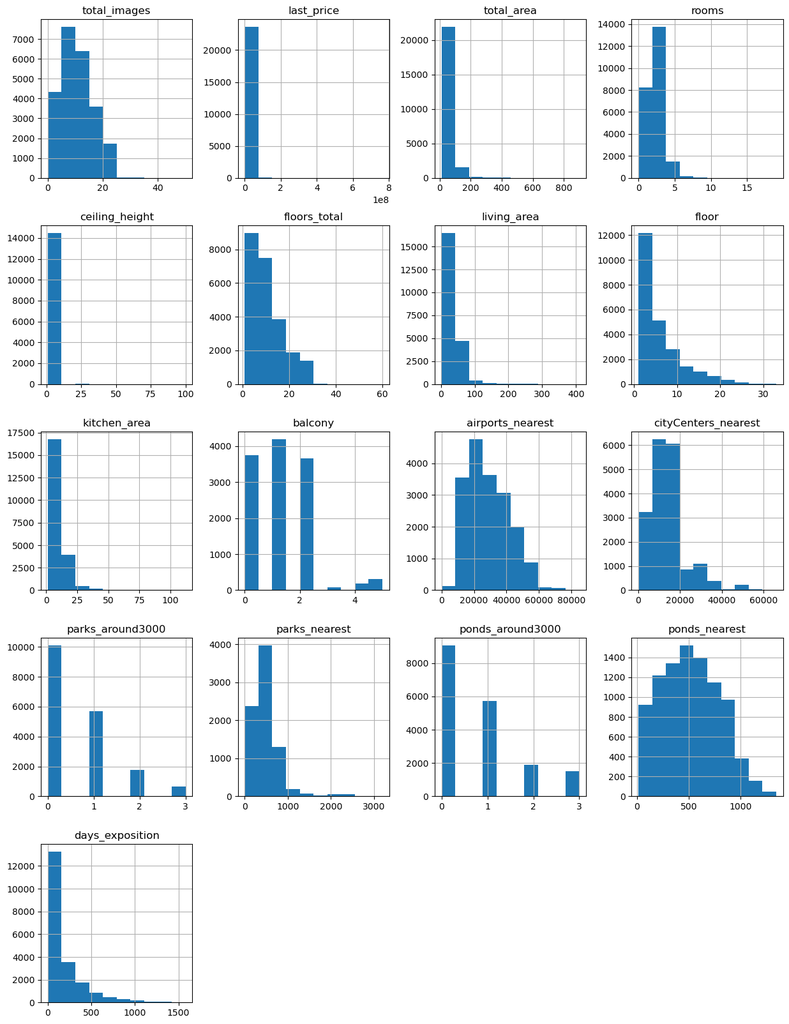

```python
data.hist(figsize=(15, 20)); #строю гистораммы для всех числовых значений, которые есть в таблице
```

```python
corr_matrix = data.corr() # создаю корреляционную матрицу
# окрашу матрицу с помощью градиента от холодного(синего) к теплому(красному)
corr_matrix.style.background_gradient(cmap='coolwarm')
```

|  | total_images | last_price | total_area | rooms | ceiling_height | floors_total | living_area | floor | studio | open_plan | kitchen_area | balcony | airports_nearest | cityCenters_nearest | parks_around3000 | parks_nearest | ponds_around3000 | ponds_nearest | days_exposition |
| --- | --- | --- | --- | --- | --- | --- | --- | --- | --- | --- | --- | --- | --- | --- | --- | --- | --- | --- | --- |
| total_images | 1.000000 | 0.104473 | 0.115352 | 0.099288 | -0.001987 | 0.010427 | 0.104780 | 0.031340 | -0.029303 | -0.024407 | 0.104756 | 0.121693 | -0.002298 | -0.047666 | 0.021120 | -0.008347 | -0.011553 | -0.003034 | -0.026657 |
| last_price | 0.104473 | 1.000000 | 0.653675 | 0.363343 | 0.085430 | -0.006984 | 0.566492 | 0.026576 | -0.025362 | -0.008802 | 0.519869 | 0.029646 | -0.026239 | -0.206747 | 0.151058 | -0.016414 | 0.159996 | -0.084809 | 0.081146 |
| total_area | 0.115352 | 0.653675 | 1.000000 | 0.758344 | 0.095490 | -0.075774 | 0.939537 | -0.024754 | -0.072653 | -0.034885 | 0.609121 | 0.047937 | -0.030753 | -0.231446 | 0.164689 | -0.021497 | 0.162346 | -0.097969 | 0.149675 |
| rooms | 0.099288 | 0.363343 | 0.758344 | 1.000000 | 0.054457 | -0.228215 | 0.845977 | -0.150862 | -0.147286 | -0.087500 | 0.269945 | 0.017991 | -0.061199 | -0.184864 | 0.137257 | -0.054549 | 0.092693 | -0.057689 | 0.126961 |
| ceiling_height | -0.001987 | 0.085430 | 0.095490 | 0.054457 | 1.000000 | -0.028732 | 0.090650 | -0.011798 | 0.001674 | 0.042777 | 0.087641 | 0.040523 | -0.023947 | -0.091689 | 0.065915 | -0.019167 | 0.078209 | -0.059090 | 0.019091 |
| floors_total | 0.010427 | -0.006984 | -0.075774 | -0.228215 | -0.028732 | 1.000000 | -0.169311 | 0.678059 | 0.070151 | 0.050791 | 0.163944 | 0.194065 | 0.108288 | 0.019774 | -0.252833 | 0.097527 | -0.122735 | 0.038864 | -0.052234 |
| living_area | 0.104780 | 0.566492 | 0.939537 | 0.845977 | 0.090650 | -0.169311 | 1.000000 | -0.097210 | -0.056231 | -0.033711 | 0.428674 | 0.018849 | -0.057912 | -0.231368 | 0.184453 | -0.050167 | 0.148933 | -0.081674 | 0.142454 |
| floor | 0.031340 | 0.026576 | -0.024754 | -0.150862 | -0.011798 | 0.678059 | -0.097210 | 1.000000 | 0.036940 | 0.035824 | 0.135531 | 0.168773 | 0.071597 | 0.009084 | -0.163784 | 0.073045 | -0.076312 | 0.024850 | -0.039463 |
| studio | -0.029303 | -0.025362 | -0.072653 | -0.147286 | 0.001674 | 0.070151 | -0.056231 | 0.036940 | 1.000000 | -0.004235 | nan | 0.031455 | -0.021876 | -0.007029 | -0.030202 | 0.009134 | 0.000939 | 0.002606 | -0.022476 |
| open_plan | -0.024407 | -0.008802 | -0.034885 | -0.087500 | 0.042777 | 0.050791 | -0.033711 | 0.035824 | -0.004235 | 1.000000 | nan | 0.019491 | -0.013583 | -0.004204 | -0.010077 | 0.010612 | 0.008455 | -0.003328 | -0.024112 |
| kitchen_area | 0.104756 | 0.519869 | 0.609121 | 0.269945 | 0.087641 | 0.163944 | 0.428674 | 0.135531 | nan | nan | 1.000000 | 0.098634 | 0.008200 | -0.190049 | 0.087503 | 0.029641 | 0.150148 | -0.105223 | 0.100586 |
| balcony | 0.121693 | 0.029646 | 0.047937 | 0.017991 | 0.040523 | 0.194065 | 0.018849 | 0.168773 | 0.031455 | 0.019491 | 0.098634 | 1.000000 | 0.066834 | 0.051051 | -0.082850 | 0.052328 | -0.032709 | 0.010847 | -0.032909 |
| airports_nearest | -0.002298 | -0.026239 | -0.030753 | -0.061199 | -0.023947 | 0.108288 | -0.057912 | 0.071597 | -0.021876 | -0.013583 | 0.008200 | 0.066834 | 1.000000 | 0.272184 | 0.000759 | -0.070058 | -0.049583 | 0.014049 | -0.018271 |
| cityCenters_nearest | -0.047666 | -0.206747 | -0.231446 | -0.184864 | -0.091689 | 0.019774 | -0.231368 | 0.009084 | -0.007029 | -0.004204 | -0.190049 | 0.051051 | 0.272184 | 1.000000 | -0.161738 | -0.040650 | -0.074577 | 0.028903 | -0.060714 |
| parks_around3000 | 0.021120 | 0.151058 | 0.164689 | 0.137257 | 0.065915 | -0.252833 | 0.184453 | -0.163784 | -0.030202 | -0.010077 | 0.087503 | -0.082850 | 0.000759 | -0.161738 | 1.000000 | -0.259514 | 0.304316 | -0.167103 | 0.060491 |
| parks_nearest | -0.008347 | -0.016414 | -0.021497 | -0.054549 | -0.019167 | 0.097527 | -0.050167 | 0.073045 | 0.009134 | 0.010612 | 0.029641 | 0.052328 | -0.070058 | -0.040650 | -0.259514 | 1.000000 | 0.077280 | 0.000692 | 0.023254 |
| ponds_around3000 | -0.011553 | 0.159996 | 0.162346 | 0.092693 | 0.078209 | -0.122735 | 0.148933 | -0.076312 | 0.000939 | 0.008455 | 0.150148 | -0.032709 | -0.049583 | -0.074577 | 0.304316 | 0.077280 | 1.000000 | -0.341840 | 0.073162 |
| ponds_nearest | -0.003034 | -0.084809 | -0.097969 | -0.057689 | -0.059090 | 0.038864 | -0.081674 | 0.024850 | 0.002606 | -0.003328 | -0.105223 | 0.010847 | 0.014049 | 0.028903 | -0.167103 | 0.000692 | -0.341840 | 1.000000 | -0.077879 |
| days_exposition | -0.026657 | 0.081146 | 0.149675 | 0.126961 | 0.019091 | -0.052234 | 0.142454 | -0.039463 | -0.022476 | -0.024112 | 0.100586 | -0.032909 | -0.018271 | -0.060714 | 0.060491 | 0.023254 | 0.073162 | -0.077879 | 1.000000 |

С помощью матрицы можно определить, есть ли зависимость одних показателей таблицы от других показателей.

В данном случае я вижу, что есть положительная корреляция между стоимостью объекта недвижимости и его общей площадью, между количеством комнат и общей площадью, между общей площадью и жилой площадью. Также я вижу небольшую отрицательную корреляцию.

Эта информация может нам понадобится в ходе дальнейшего анализа данных.

Прочитав общую информацию о таблице, я могу сделать следующие **предварительные выводы**:

- столбец `first_day_exposition` нужно привести к типу data
- столбец `ceiling_height` имеет пропуски
- столбец `floors_total` можно привести к типу `int64`, т.к количество этажей - это целое число, также имеются пропуски
- столбец `living_area` имеет пропуски
- стобец `is_apartment` имеет пропуски, также в описании задачи сказано, что он должен иметь тип `bool`, а в таблице этот столбец имеет тип `object`, необходимо привети к типу `bool`
- столбец `kitchen_area` имеет пропуски
- столбец `balcony`можно привести к типу `int64`, т.к количество балконов - это целое число, также имеются пропуски
- столбец `locality_name` имеет пропуски
- столбец `airports_nearest` имеет пропуски
- столбец `cityCenters_nearest` имеет пропуски, также можно привести название столбца к удобному виду
- столбец `parks_around3000` имеет пропуски, можно привести к типу `int64`, т.к. количество парков считается в целыми числами
- столбец `parks_nearest` имеет пропуски
- столбец `ponds_around3000` имеет пропуски, можно привести к типу `int64`, т.к. количество водоемов считается в целыми числами
- столбец `ponds_nearest` имеет пропуски
- столбец `days_exposition` имеет пропуски, можно привести к типу `int64`, т.к. количество дней считается целыми числами

### Предобработка данных

С помощью метода `fillna()` заменю все пустые значения в столбцах, где считаю это возможным, без ущерба данным.

С помощью метода `astype()` изменю типы данных в столбцах

С помощью метода `rename` изменю имя столбца `cityCenters_nearest`

С помощью функции `to_datetime` изменю тип данных в столбце `first_day_exposition`

```python
data['first_day_exposition'] = pd.to_datetime(data['first_day_exposition'], format='%Y-%m-%d') # заменяю тип на datetime
```

```python
data['balcony'] = data['balcony'].fillna(0).astype(int) # заменяю пустые значения на 0, изменяю тип на int
```

```python
data['is_apartment'] = data['is_apartment'].fillna(0).astype(bool) # заменяю пустые значения на 0, изменяю тип на bool
```

```python
data['days_exposition'] = data['days_exposition'].fillna(0).astype(int) # заменяю пустые значения на 0, изменяю тип на int
```

```python
data.rename(columns ={'cityCenters_nearest':'city_centers_nearest'}, inplace = True) # переименовываю столбец
```

Я заменила пропуски нулями в столбцах balcony, is_apartment, т.к. посчитала, что это логично и не навредит дальнейшему анализу. Я вижу, что все столбцы с данными загруженными с геосервисов имеют большое количество пропусков. Из данных добавленных пользователем имеются пропуски в данных о высоте потолков, количестве этажей в доме, жилой площади и площади кухни, а также в названии населенного пункта. Эти пропуски я пока трогать не буду.

Поработаю со столбцом `locality_name`. Для начала издавимся от явных дубликатов и заменим все буквы "ё" на "е".

```python
data.locality_name = data.locality_name.str.replace('ё', 'е')
```

Разделю данные в столбце `locality_name`. Осталю в нем наименование населенного пункта, а тип населенного пункта перенесу в новый столбец. Назову новый столбец `locality_type`. Для этого введу собственную функцию, которая будет возвращать все слова с маленькой буквы и добавлю эти слова в новый столбец. Т.к. наименование населенного пункта в таблице указаны с большой буквы в новый столбец добавятся как раз типы населенных пунктов.

```python
def title_parse(title):
    res = ' '.join(word for word in title.split(' ') if word.islower())
    return res
```

```python
data['locality_type'] = data.locality_name.fillna('').apply(title_parse)
```

```python
data[['locality_name', 'locality_type']].head(10)
```

|  | locality_name | locality_type |
| --- | --- | --- |
| 0 | Санкт-Петербург |  |
| 1 | поселок Шушары | поселок |
| 2 | Санкт-Петербург |  |
| 3 | Санкт-Петербург |  |
| 4 | Санкт-Петербург |  |
| 5 | городской поселок Янино-1 | городской поселок |
| 6 | поселок Парголово | поселок |
| 7 | Санкт-Петербург |  |
| 8 | поселок Мурино | поселок |
| 9 | Санкт-Петербург |  |

```python
data['locality_type'].unique()
```

```
array(['', 'поселок', 'городской поселок', 'деревня',
       'поселок городского типа', 'садовое товарищество', 'село',
       'поселок городского типа имени', 'поселок станции',
       'садоводческое некоммерческое товарищество',
       'поселок 69-й километр', 'поселок при железнодорожной станции',
       'коттеджный поселок'], dtype=object)
```

Теперь уникальных значений гораздо меньше и я вижу дубликаты. Заменю типы населенных пунктов в столбце locality_name

```python
data.locality_name = (
    data.locality_name.str.replace('городской поселок', 'поселок городского типа')
    .replace('садоводческое некоммерческое товарищество', 'садовое товарищество')
    .replace('поселок станции', 'поселок при железнодорожной станции')
)
```

Проверю, что получилось. Перезапишу данные в столбец locality_type и выведу уникальные значения на экран

```python
data['locality_type'] = data.locality_name.fillna('').apply(title_parse)
data['locality_type'].unique()
```

```
array(['', 'поселок', 'поселок городского типа', 'деревня',
       'садовое товарищество', 'село', 'поселок городского типа имени',
       'поселок станции', 'садоводческое некоммерческое товарищество',
       'поселок 69-й километр', 'поселок при железнодорожной станции',
       'коттеджный поселок'], dtype=object)
```

```
Проведу проверку на выявление явных дубликатов и подсчитаю их сумму.
```

```python
data.duplicated().sum()
```

```
0
```

**Вывод:**

### Посчитайте и добавьте в таблицу новые столбцы

Добавлю в таблицу новый столбец `price_metr` и внесу в него цену одного квадратного метра. Для этого поделю значения столбца `last_price` на значения столбца `total_area`. Для того чтобы округлить значения до 2х знаков после запятой воспользуюсь функцией `round()`

```python
data['price_metr'] = (data['last_price'] / data['total_area']).round(2)
display(data['price_metr'])
```

```
0        120370.37
1         82920.79
2         92785.71
3        408176.10
4        100000.00
           ...
23694     72490.85
23695     52542.37
23696     44091.71
23697    149511.40
23698     41795.67
Name: price_metr, Length: 23699, dtype: float64
```

Добавлю столбцы со значениями дня недели публикации, месяца и года публикации. Назову их `weekday`, `month_publication`, `year_publication`.

Для того чтобы найти день недели публикации воспользуюсь методом `weekday` и добалю новы столбец в котором отражаются дни недели в виде цифр, где 0 - понедельник а 6 - воскресенье.

Для вывода месяца и года публикации воспользуюсь методами `month` и `year` соответстввенно.

```python
data['weekday'] = data['first_day_exposition'].dt.weekday # определяю день недели
data['month_publication'] = pd.DatetimeIndex(data['first_day_exposition']).month # вывожу отдельно месяц публикации
data['year_publication'] = pd.DatetimeIndex(data['first_day_exposition']).year # вывожу отдельно год публикации
display(data) # вывожу на экран таблицу
```

|  | total_images | last_price | total_area | first_day_exposition | rooms | ceiling_height | floors_total | living_area | floor | is_apartment | ... | parks_around3000 | parks_nearest | ponds_around3000 | ponds_nearest | days_exposition | locality_type | price_metr | weekday | month_publication | year_publication |
| --- | --- | --- | --- | --- | --- | --- | --- | --- | --- | --- | --- | --- | --- | --- | --- | --- | --- | --- | --- | --- | --- |
| 0 | 20 | 13000000.0 | 108.00 | 2019-03-07 | 3 | 2.70 | 16.0 | 51.0 | 8 | False | ... | 1.0 | 482.0 | 2.0 | 755.0 | 0 |  | 120370.37 | 3 | 3 | 2019 |
| 1 | 7 | 3350000.0 | 40.40 | 2018-12-04 | 1 | NaN | 11.0 | 18.6 | 1 | False | ... | 0.0 | NaN | 0.0 | NaN | 81 | поселок | 82920.79 | 1 | 12 | 2018 |
| 2 | 10 | 5196000.0 | 56.00 | 2015-08-20 | 2 | NaN | 5.0 | 34.3 | 4 | False | ... | 1.0 | 90.0 | 2.0 | 574.0 | 558 |  | 92785.71 | 3 | 8 | 2015 |
| 3 | 0 | 64900000.0 | 159.00 | 2015-07-24 | 3 | NaN | 14.0 | NaN | 9 | False | ... | 2.0 | 84.0 | 3.0 | 234.0 | 424 |  | 408176.10 | 4 | 7 | 2015 |
| 4 | 2 | 10000000.0 | 100.00 | 2018-06-19 | 2 | 3.03 | 14.0 | 32.0 | 13 | False | ... | 2.0 | 112.0 | 1.0 | 48.0 | 121 |  | 100000.00 | 1 | 6 | 2018 |
| ... | ... | ... | ... | ... | ... | ... | ... | ... | ... | ... | ... | ... | ... | ... | ... | ... | ... | ... | ... | ... | ... |
| 23694 | 9 | 9700000.0 | 133.81 | 2017-03-21 | 3 | 3.70 | 5.0 | 73.3 | 3 | False | ... | 1.0 | 796.0 | 3.0 | 381.0 | 0 |  | 72490.85 | 1 | 3 | 2017 |
| 23695 | 14 | 3100000.0 | 59.00 | 2018-01-15 | 3 | NaN | 5.0 | 38.0 | 4 | False | ... | NaN | NaN | NaN | NaN | 45 |  | 52542.37 | 0 | 1 | 2018 |
| 23696 | 18 | 2500000.0 | 56.70 | 2018-02-11 | 2 | NaN | 3.0 | 29.7 | 1 | False | ... | NaN | NaN | NaN | NaN | 0 | село | 44091.71 | 6 | 2 | 2018 |
| 23697 | 13 | 11475000.0 | 76.75 | 2017-03-28 | 2 | 3.00 | 17.0 | NaN | 12 | False | ... | 2.0 | 173.0 | 3.0 | 196.0 | 602 |  | 149511.40 | 1 | 3 | 2017 |
| 23698 | 4 | 1350000.0 | 32.30 | 2017-07-21 | 1 | 2.50 | 5.0 | 12.3 | 1 | False | ... | NaN | NaN | NaN | NaN | 0 | поселок | 41795.67 | 4 | 7 | 2017 |

23699 rows × 27 columns

Разделю объявления на категории по типу этажа квартиры. Добавим 3 категории:

- первый (в этой категории будут квартиры размещенные на первых этажах здания);
- последний (в этой категории будут квартиры размещенные на последнем этаже здания);
- другой (в этой категории будут все остальные квартиры).

Для этого напишу функцию категоризации по этажам, используя метод apply добавлю значения полученные функцией в новый столбец

```python
# напишу собственную функцию
def floor_type(row):
    floors_total = row['floors_total']
    floor = row['floor']
    if floor == 1:
        return 'первый'
    elif floor == floors_total:
        return 'последний'
    elif 1 < floor < floors_total:
        return 'другой'
```

```python
data['floor_type'] = data.apply(floor_type, axis = 1) # добавляю значения в новый столбец
display(data['floor_type'].head(15)) # выведу первые 15 строк на экран
```

```
0        другой
1        первый
2        другой
3        другой
4        другой
5        другой
6        другой
7        другой
8        другой
9        другой
10       другой
11       другой
12    последний
13    последний
14       первый
Name: floor_type, dtype: object
```

Добавлю новый столбец в котором будет указано растояние до центра города в километрых. Для этого разделю значения столбца `city_centers_nearest` на 1000 и округлю до ближайших целых значений. Заменю пустые значения в новом столбце на 999999, т.к. предпологаю, что если не указано растояние до центра, то оно большое. Приведу столбец к типу `int`.

```python
data['city_centers_nearest_in_km'] = data['city_centers_nearest'] / 1000
data['city_centers_nearest_in_km'] = data['city_centers_nearest_in_km'].round()
data['city_centers_nearest_in_km'] = data['city_centers_nearest_in_km'].fillna(999999)
data['city_centers_nearest_in_km'] = data['city_centers_nearest_in_km'].astype('int')
print(data['city_centers_nearest_in_km'])
```

```
0            16
1            19
2            14
3             7
4             8
          ...
23694         4
23695    999999
23696    999999
23697        10
23698    999999
Name: city_centers_nearest_in_km, Length: 23699, dtype: int32
```

**Вывод:** Я добавила в таблицу столбцы с следующими параметрами:

- цена одного квадратного метра;
- день недели публикации объявления;
- месяц публикации объявления;
- год публикации объявления;
- тип этажа квартиры;
- расстояние до центра города в километрах.

### Проведите исследовательский анализ данных

```
count    23699.000000
mean        60.348651
std         35.654083
min         12.000000
25%         40.000000
50%         52.000000
75%         69.900000
max        900.000000
Name: total_area, dtype: float64
```

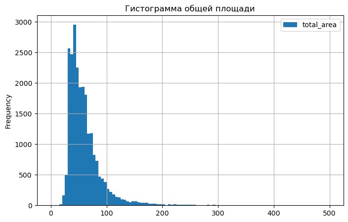

```python
#изучу общую площадь
# вывожу гистограмму
data.plot(y = 'total_area', kind = 'hist', bins = 100, grid=True, figsize = (8, 5), range = (0, 500),
          title='Гистограмма общей площади')
data['total_area'].describe() # вывожу сводные данные
```

```python
# посчитаю количество квартир площадью более 400 кв.м.
data.query('total_area >= 400').groupby(['total_area'], as_index=False)['last_price'].count()
```

|  | total_area | last_price |
| --- | --- | --- |
| 0 | 400.00 | 3 |
| 1 | 401.00 | 1 |
| 2 | 402.00 | 1 |
| 3 | 410.00 | 1 |
| 4 | 413.50 | 1 |
| 5 | 422.20 | 1 |
| 6 | 431.00 | 1 |
| 7 | 441.98 | 1 |
| 8 | 460.80 | 1 |
| 9 | 470.30 | 1 |
| 10 | 483.90 | 1 |
| 11 | 488.00 | 1 |
| 12 | 491.00 | 1 |
| 13 | 494.10 | 1 |
| 14 | 495.00 | 1 |
| 15 | 500.00 | 2 |
| 16 | 507.00 | 1 |
| 17 | 517.00 | 1 |
| 18 | 590.00 | 1 |
| 19 | 618.00 | 1 |
| 20 | 631.00 | 1 |
| 21 | 631.20 | 1 |
| 22 | 900.00 | 1 |

```python
# посчитаю количество квартир площадью менее 18 кв.м.
data.query('total_area <= 18').groupby(['total_area'], as_index=False)['last_price'].count()
```

|  | total_area | last_price |
| --- | --- | --- |
| 0 | 12.00 | 1 |
| 1 | 13.00 | 3 |
| 2 | 13.20 | 1 |
| 3 | 14.00 | 1 |
| 4 | 15.00 | 2 |
| 5 | 15.50 | 1 |
| 6 | 16.00 | 1 |
| 7 | 17.00 | 2 |
| 8 | 17.20 | 1 |
| 9 | 17.60 | 1 |
| 10 | 17.78 | 1 |
| 11 | 18.00 | 5 |

```python
data = data[data['total_area'] <= 400]
data = data[data['total_area'] > 18]
```

```
count    23656.000000
mean        59.950432
std         32.634056
min         18.400000
25%         40.000000
50%         52.000000
75%         69.700000
max        400.000000
Name: total_area, dtype: float64
```

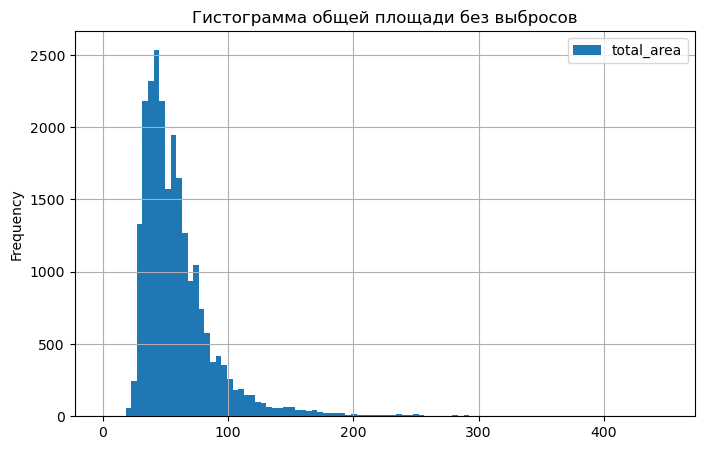

```python
# выведу обновленные сводные данные по столбцу total_area
data.plot(y = 'total_area', kind = 'hist', bins = 100, grid=True, figsize = (8, 5), range = (0, 450),
          title='Гистограмма общей площади без выбросов')
data['total_area'].describe()
```

С помощью метода `plot` построила гистограмму столбца `total_area`. Распределение нормальное, имеются выбросы.

С помощью метода `discribe()` получила общее представление о данных в столбце.

С помощью методов `query` и `groupby` нашла выбивающиеся, на мой взляд, значения и удалила их из таблицы.

**Вывод:** Основной объем квартир в иследовании составляют квартиры общей площадью до 100 кв.м. Больше всего квартир площадью 40 - 50 кв.м.

```
count    21766.000000
mean        34.280918
std         20.844158
min          2.000000
25%         18.600000
50%         30.000000
75%         42.300000
max        264.500000
Name: living_area, dtype: float64
```

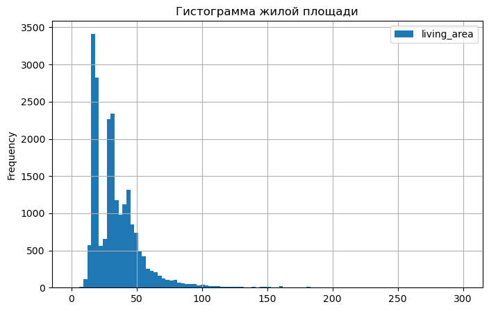

```python
#изучим жилую площадь
# вывожу гистограмму
data.plot(y = 'living_area', kind = 'hist', bins = 100, grid=True, figsize = (8, 5), range = (0, 300),
          title='Гистограмма жилой площади')
data['living_area'].describe() # вывожу сводные данные
```

```python
data = data[(data['living_area'] >= 6) | (data['living_area'].isna())] #удаляю из таблицы данные с жилой площадью менее 6 кв.м.
```

```
count    21760.000000
mean        34.289433
std         20.840710
min          6.000000
25%         18.600000
50%         30.000000
75%         42.300000
max        264.500000
Name: living_area, dtype: float64
```

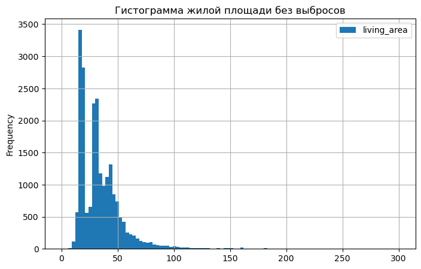

```python
# выведу обновленные сводные данные по столбцу living_area
data.plot(y = 'living_area', kind = 'hist', bins = 100, grid=True, figsize = (8, 5), range = (0, 300),
          title='Гистограмма жилой площади без выбросов')
data['living_area'].describe()
```

С помощью метода `plot` построила гистограмму столбца `living_area`. Распределение нормальное, имеются выбросы. Вижу 3 пика на гистограмме, но считаю данные корректными и подходящими для дальнейшего анализа.

Поискав в интернете выяснила, что минимальная жилая площадь не может быть меньше 6 кв.м., в связи с этим удалила данные из таблицы, где значение столбца `living_area` менее 6, приняв их за ошибочные данные.

С помощью метода `discribe()` получила общее представление о данных в столбце.

**Вывод:** Больше всего объявлений о продаже квартир с жилой площадью 18-19 кв.м. и квартир с жилой площадью около 30 кв.м. и 40-45 кв.м.

```
count    21394.000000
mean        10.538571
std          5.762207
min          1.300000
25%          7.000000
50%          9.100000
75%         12.000000
max        107.000000
Name: kitchen_area, dtype: float64
```

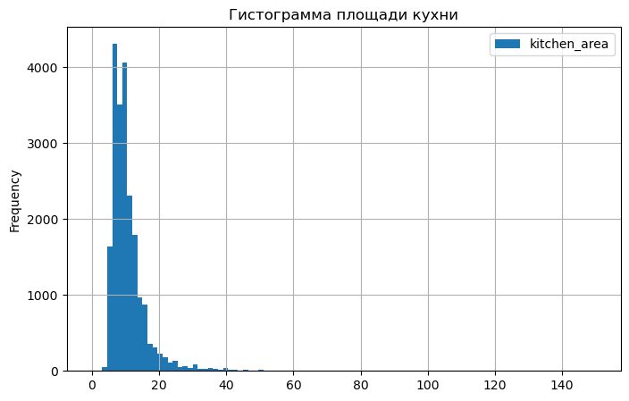

```python
#изучим площадь кухни
# вывожу гистограмму
data.plot(y = 'kitchen_area', kind = 'hist', bins = 100, grid=True, figsize = (8, 5), range = (0, 150),
          title='Гистограмма площади кухни')
data['kitchen_area'].describe() # вывожу общие данные
```

С помощью метода `plot` построила гистограмму по столбцу `kitchen_area`. Распределение нормальное, имеются выбросы, но они не сильно влияют на данные.

С помощью метода `discribe()` получила общее представление о данных в столбце.

**Вывод:** Основную массу объявлений, в которых указана площадь кухни, составляют квартиры с размером кухни от 5 до 15 кв.м.

```
count    2.365000e+04
mean     6.425801e+06
std      9.585983e+06
min      1.219000e+04
25%      3.420000e+06
50%      4.650000e+06
75%      6.790000e+06
max      7.630000e+08
Name: last_price, dtype: float64
```

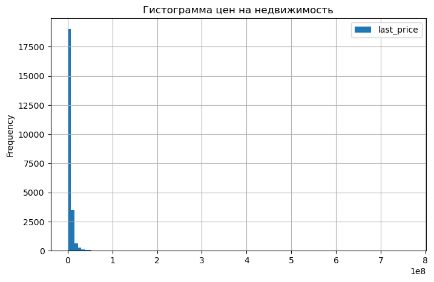

```python
#изучим цену объекта недвижимости
# вывожу гистограмму
data.plot(y = 'last_price', kind = 'hist', bins = 100, grid=True, figsize = (8, 5),
          title='Гистограмма цен на недвижимость')
data['last_price'].describe() # вывожу общие данные
```

С помощью метода `plot` построила гистограмму по столбцу `last_price`. Распределение нормальное.

С помощью метода `discribe()` вывела общие сведения о данных в столбце, однако они отразились в виду экспоненциальной записи числа, что не очень читаемо.

**Вывод:** В среднем стоимость квартир входит в диапазон от 4.5 до 6.5 млн.

```
count    23650.000000
mean         2.067696
std          1.067168
min          0.000000
25%          1.000000
50%          2.000000
75%          3.000000
max         19.000000
Name: rooms, dtype: float64
```

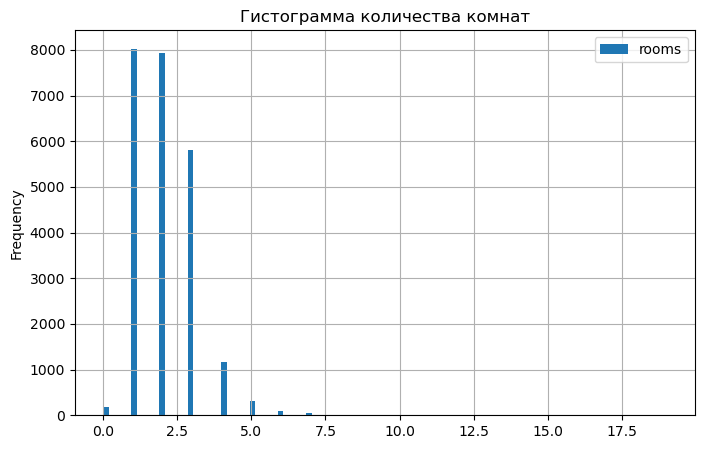

```python
#изучим количество комнат
# вывожу гистограмму
data.plot(y = 'rooms', kind = 'hist', bins = 100, grid=True, figsize = (8, 5),
          title='Гистограмма количества комнат')
data['rooms'].describe() # вывожу общие сведения о столбце
```

```python
# сгруппирую данные по количеству комнат и отсортирую по убыванию
print(data.groupby('rooms')['rooms'].count().sort_values(ascending=False))
```

```
rooms
1     8029
2     7939
3     5813
4     1176
5      321
0      191
6      101
7       51
8       12
9        8
10       3
11       2
14       2
16       1
19       1
Name: rooms, dtype: int64
```

```python
# удалю из данных квартиры с количеством комнато более 8
data = data[(data['rooms'] < 8) | (data['rooms'].isna())]
```

```
count    23621.000000
mean         2.058253
std          1.029000
min          0.000000
25%          1.000000
50%          2.000000
75%          3.000000
max          7.000000
Name: rooms, dtype: float64
```

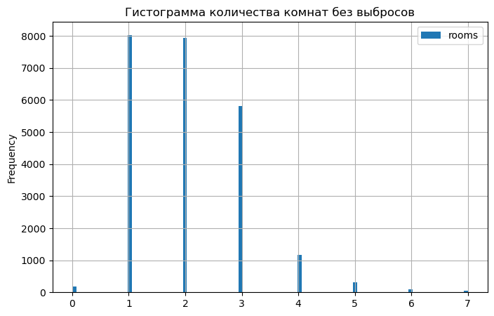

```python
# выведу обновленные сводные данные по столбцу rooms
data.plot(y = 'rooms', kind = 'hist', bins = 100, grid=True, figsize = (8, 5),
          title='Гистограмма количества комнат без выбросов')
data['rooms'].describe()
```

С помощью метода `plot` построила гистограмму по столбцу `rooms`. Распределение нормальное.

С помощью метода `discribe()` получила общее представление о данных в столбце.

С помощью метода `groupby` узнала, что основную массу объявлений составляют квартиры с количеством комнат менее 8. Я удалила из таблицы данные о квартирах имеющих более 7 комнат, т.к. приняла эти данные за редкие и выбивающиеся значения.

**Вывод:** Основную массу объвлений составляют квартиры с 1 и 2 комнатами, чуть меньше 3 комнатных квартир.

```
count    14454.000000
mean         2.770078
std          1.262675
min          1.000000
25%          2.510000
50%          2.650000
75%          2.800000
max        100.000000
Name: ceiling_height, dtype: float64
```

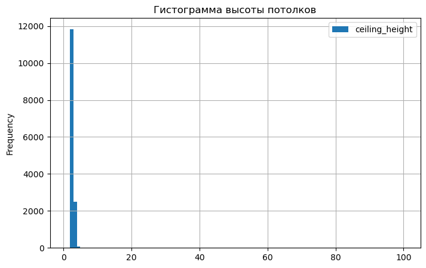

```python
#изучим высоту потолков
# вывожу гистограмму
data.plot(y = 'ceiling_height', kind = 'hist', bins = 100, grid=True, figsize = (8, 5),
          title='Гистограмма высоты потолков')
data['ceiling_height'].describe() # вывожу сводные данные
```

```python
#сгрупирую данные по высоте потолков и выведу на экран квартиры с потолкам более 5 м.
data.query('ceiling_height >= 5').groupby(['ceiling_height'], as_index=False)['last_price'].count()
```

|  | ceiling_height | last_price |
| --- | --- | --- |
| 0 | 5.0 | 1 |
| 1 | 5.2 | 1 |
| 2 | 5.3 | 2 |
| 3 | 5.5 | 1 |
| 4 | 5.6 | 1 |
| 5 | 5.8 | 1 |
| 6 | 6.0 | 1 |
| 7 | 8.0 | 3 |
| 8 | 8.3 | 1 |
| 9 | 10.3 | 1 |
| 10 | 14.0 | 1 |
| 11 | 20.0 | 1 |
| 12 | 22.6 | 1 |
| 13 | 24.0 | 1 |
| 14 | 25.0 | 7 |
| 15 | 26.0 | 1 |
| 16 | 27.0 | 8 |
| 17 | 27.5 | 1 |
| 18 | 32.0 | 2 |
| 19 | 100.0 | 1 |

```python
# напишу собственную фунцию для замены ошибочных значений в столбце
def ceiling(row):
    ceiling_height = row['ceiling_height']
    if ceiling_height >= 20:
        return ceiling_height / 10
    else:
        return ceiling_height

data['ceiling_height'] = data.apply(ceiling, axis = 1).round(1) # обновлю значения в столбце и округю до 1 знака после точки
```

```python
# удалю из таблицы квартиры с высотой потолков более 5 м. и менее 2 м.
data = data[(data['ceiling_height'] < 5) | (data['ceiling_height'].isna())]
data = data[(data['ceiling_height'] > 2) | (data['ceiling_height'].isna())]
```

```python
print(data['ceiling_height'].unique())
```

```
[2.7 nan 3.  2.5 2.6 2.8 2.9 3.2 3.4 4.2 3.5 3.3 4.  3.1 2.3 3.7 2.4 3.6
 3.8 4.1 4.7 3.9 4.8 4.5 4.4 4.3 2.2 4.9]
```

```
count    14424.000000
mean         2.728369
std          0.268351
min          2.200000
25%          2.500000
50%          2.600000
75%          2.800000
max          4.900000
Name: ceiling_height, dtype: float64
```

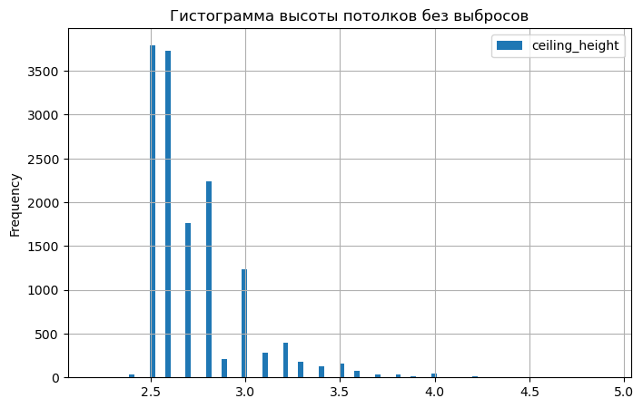

```python
# выведу обновленные сведения
data.plot(y = 'ceiling_height', kind = 'hist', bins = 100, grid=True, figsize = (8, 5),
          title='Гистограмма высоты потолков без выбросов')
data['ceiling_height'].describe()
```

С помощью метода `plot` построила гистограмму по столбцу `ceiling_height`. Распределение нормальное.

С помощью метода `discribe()` получила общее представление о данных в столбце.

С помощью метода `groupby` выявила потолки высотой более 5 м. Выяснила, что есть потолки высотой от 20 м, считаю эти значеня ошибочными. Написала функцию которая делит значение строки ceiling_height на 10, если это значение больше 20. Таким образом я исправила ошибки совершенные пользователями при вводе данных. После применения фунции оставшиеся значения более 5 я удалила из таблицы, т.к. считаю эти данные не корректными, да и достаточно редкими.

**Вывод:** Большинство квартир имеет высоту потолков 2.5 м и 2.6 м. Квартир с высотой потолков более 3 м очень мало.

```
Axes(0.125,0.11;0.775x0.77)
```

```
count      23508
unique         3
top       другой
freq       17311
Name: floor_type, dtype: object
```

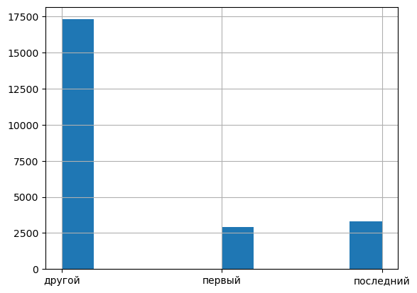

```python
#изучим тип этажа
# вывожу гистограмму
print(data['floor_type'].hist())
data['floor_type'].describe() # вывожу сводные данные
```

```python
#сгрупирую данные по типу этажа и выведем количество строк каждого типа
print(data.groupby('floor_type')['floor_type'].count().sort_values(ascending=False))
```

```
floor_type
другой       17311
последний     3302
первый        2895
Name: floor_type, dtype: int64
```

С помощью метода `hist` построила гистограмму по столбцу `floor_type`.

С помощью метода `discribe()` получила общее представление о данных в столбце.

**Вывод:** Больше всего квартир на этажах типа "другой", квартир в объявлениях на первом этаже меньше всего.

```
count    23505.000000
mean        10.686322
std          6.597898
min          1.000000
25%          5.000000
50%          9.000000
75%         16.000000
max         60.000000
Name: floors_total, dtype: float64
```

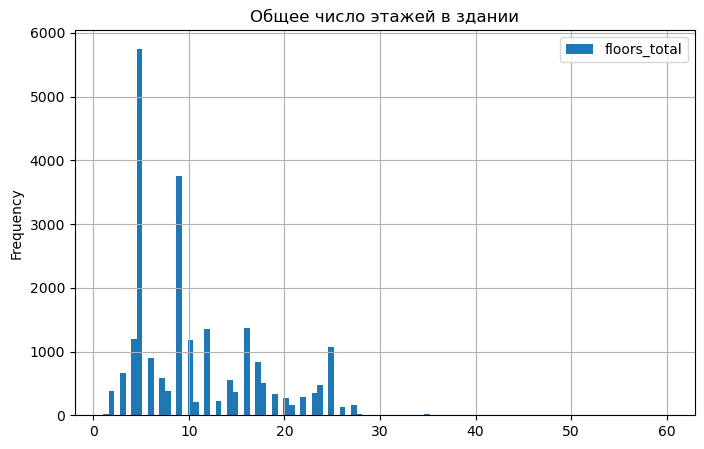

```python
#изучим общее кол-во этажей
# вывожу гистограмму
data.plot(y = 'floors_total', kind = 'hist', bins = 100, grid=True, figsize = (8, 5),
          title='Общее число этажей в здании')
data['floors_total'].describe() # вывожу сводные данные
```

```python
# удаляю значения больше 30
data = data[(data['floors_total'] < 30) | (data['ceiling_height'].isna())]
```

```python
print(data['floors_total'].unique())
```

```
[16. 11.  5. 14. 12. 26. 24. 27.  9.  6. 17. 25.  3. 23. 19. 18.  4. 22.
  8.  2. 10.  7. 13. 15. nan 20. 28. 36. 21. 35.  1. 29. 33.]
```

```
count    23492.000000
mean        10.671037
std          6.565129
min          1.000000
25%          5.000000
50%          9.000000
75%         16.000000
max         36.000000
Name: floors_total, dtype: float64
```

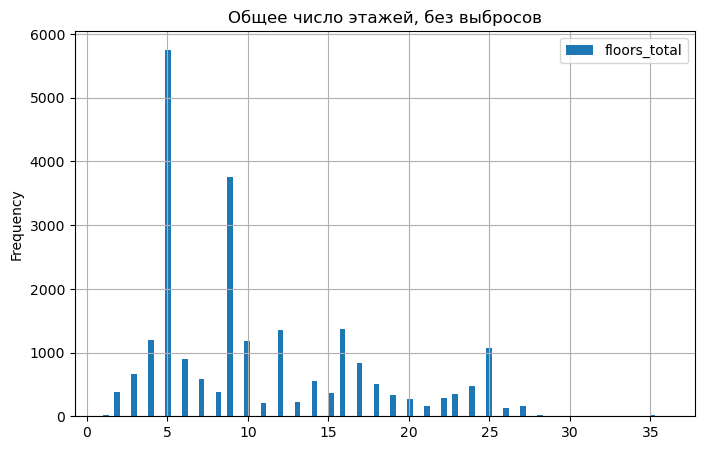

```python
# выведу обновленные сведения
data.plot(y = 'floors_total', kind = 'hist', bins = 100, grid=True, figsize = (8, 5),
          title='Общее число этажей, без выбросов')
data['floors_total'].describe()
```

С помощью метода `plot` построила гистограмму по столбцу `floors_total`.

С помощью метода `discribe()` получила общее представление о данных в столбце.

**Вывод:** Больше всего объявлений о продаже квартир в пятиэтажках, на втором месте идут девятиэтажные здания. Более, чем по 1000 объявлений в домах с этажностью в 4, 10, 12, 16 и 25 этажей.

```
count    18067.000000
mean     14217.528975
std       8606.533761
min        181.000000
25%       9279.000000
50%      13118.000000
75%      16296.000000
max      65968.000000
Name: city_centers_nearest, dtype: float64
```

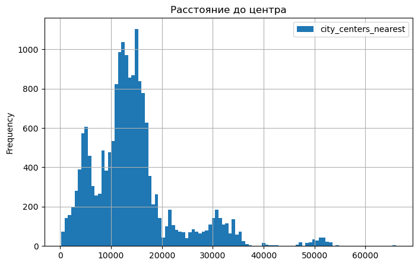

```python
#изучим расстояние до центра в метрах
# вывожу гистограмму
data.plot(y = 'city_centers_nearest', kind = 'hist', bins = 100, grid=True, figsize = (8, 5),
          title='Расстояние до центра')
data['city_centers_nearest'].describe() # вывожу сводные данные
```

С помощью метода `plot` построила гистограмму по столбцу `city_centers_nearest`. Распределение нормальное.

С помощью метода `discribe()` получила общее представление о данных в столбце.

**Вывод:** Больше всего объевлений о продаже квартир расположенных на удалении от центра до 20000 м.

```
count    8012.000000
mean      491.019221
std       342.788196
min         1.000000
25%       288.000000
50%       454.500000
75%       612.000000
max      3190.000000
Name: parks_nearest, dtype: float64
```

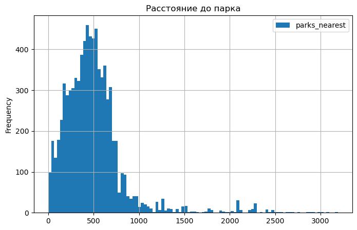

```python
#изучим расстояние до ближайшего парка
# вывожу гистограмму
data.plot(y = 'parks_nearest', kind = 'hist', bins = 100, grid=True, figsize = (8, 5),
          title='Расстояние до парка')
data['parks_nearest'].describe() # вывожу сводные данные
```

С помощью метода `plot` построила гистограмму по столбцу `parks_nearest`. Распределение нормальное. Имеются выбросы, но они не влияют на общую картину.

С помощью метода `discribe()` получила общее представление о данных в столбце.

**Вывод:** Основную массу объявлений о продаже квартир, составляют квартиры расположенные на удалении до 1000 м. от парка.

Изучу, скорось продажи квартир. Столбец `days_exposition` показывает, сколько дней было размещено каждое объявление.

Построю гистрограму с помощью метода `plot` и выведу общие сведения о столбце с помощью метода `discribe()`.

```
count    20411.000000
mean       180.649356
std        219.350770
min          1.000000
25%         45.000000
50%         95.000000
75%        231.000000
max       1580.000000
Name: days_exposition, dtype: float64
```

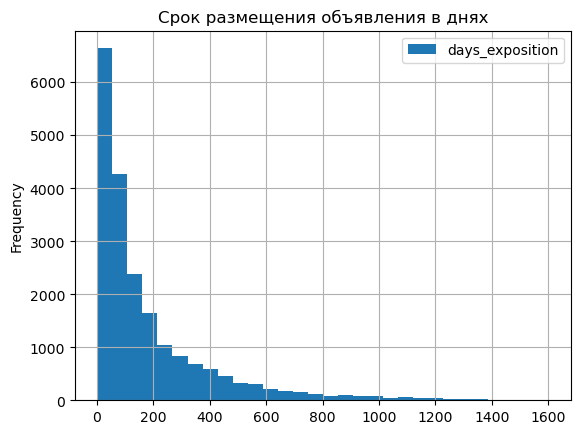

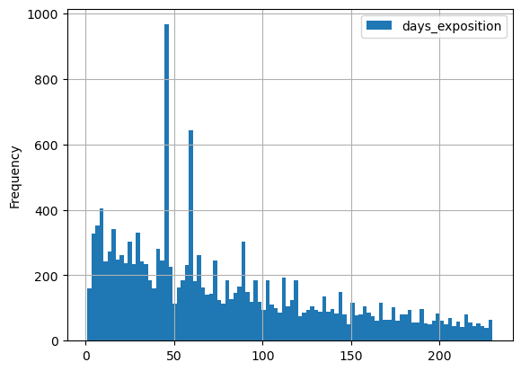

```python
# вывожу гистограмму
data.plot(y = 'days_exposition', kind = 'hist', bins = 30, grid = True, range = (1,1600),
          title='Срок размещения объявления в днях')
data.plot(y = 'days_exposition', kind = 'hist', bins = 100, grid = True, range = (1,230))

# вывожу сводные данные, исключая значения равные 0
data[data['days_exposition']!=0]['days_exposition'].describe()
```

```python
# выведу количество уникальных значений, исключая 0
data[data['days_exposition']!=0]['days_exposition'].value_counts()
```

```
45      875
60      538
7       231
30      207
90      202
       ...
1318      1
1553      1
793       1
1434      1
971       1
Name: days_exposition, Length: 1138, dtype: int64
```

```
(1.0, 1000.0)
```

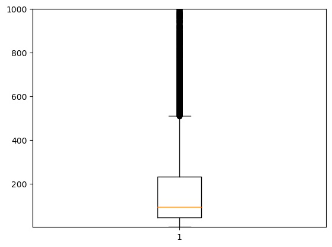

```python
#построю диаграмму размаха, исключая 0
plt.boxplot(data[data['days_exposition']!=0]['days_exposition'])
plt.ylim(1,1000)
```

```python
#выведу объявления со сроком жизни 45 дней
data[data['days_exposition']==45]
```

|  | total_images | last_price | total_area | first_day_exposition | rooms | ceiling_height | floors_total | living_area | floor | is_apartment | ... | ponds_around3000 | ponds_nearest | days_exposition | locality_type | price_metr | weekday | month_publication | year_publication | floor_type | city_centers_nearest_in_km |
| --- | --- | --- | --- | --- | --- | --- | --- | --- | --- | --- | --- | --- | --- | --- | --- | --- | --- | --- | --- | --- | --- |
| 78 | 9 | 4350000.0 | 37.0 | 2018-02-22 | 1 | NaN | 19.0 | 18.0 | 6 | False | ... | 0.0 | NaN | 45 |  | 117567.57 | 3 | 2 | 2018 | другой | 14 |
| 89 | 9 | 2500000.0 | 63.0 | 2018-10-25 | 3 | 2.5 | 5.0 | 43.0 | 4 | False | ... | NaN | NaN | 45 | поселок городского типа | 39682.54 | 3 | 10 | 2018 | другой | 999999 |
| 110 | 6 | 3850000.0 | 72.3 | 2017-09-29 | 2 | NaN | 3.0 | 27.4 | 2 | False | ... | NaN | NaN | 45 | деревня | 53250.35 | 4 | 9 | 2017 | другой | 999999 |
| 153 | 12 | 4350000.0 | 55.0 | 2017-05-21 | 2 | 2.6 | 9.0 | 31.2 | 2 | False | ... | 0.0 | NaN | 45 |  | 79090.91 | 6 | 5 | 2017 | другой | 34 |
| 158 | 15 | 3100000.0 | 47.3 | 2017-11-07 | 2 | NaN | 5.0 | 27.5 | 2 | False | ... | NaN | NaN | 45 | поселок городского типа | 65539.11 | 1 | 11 | 2017 | другой | 999999 |
| ... | ... | ... | ... | ... | ... | ... | ... | ... | ... | ... | ... | ... | ... | ... | ... | ... | ... | ... | ... | ... | ... |
| 23601 | 10 | 2900000.0 | 43.4 | 2018-01-11 | 2 | NaN | 5.0 | NaN | 1 | False | ... | 2.0 | 397.0 | 45 |  | 66820.28 | 3 | 1 | 2018 | первый | 14 |
| 23613 | 4 | 3950000.0 | 52.0 | 2018-03-04 | 3 | NaN | 5.0 | NaN | 2 | False | ... | 0.0 | NaN | 45 | поселок | 75961.54 | 6 | 3 | 2018 | другой | 21 |
| 23670 | 9 | 2450000.0 | 45.6 | 2018-02-08 | 1 | 2.8 | 9.0 | NaN | 2 | False | ... | NaN | NaN | 45 | поселок городского типа | 53728.07 | 3 | 2 | 2018 | другой | 999999 |
| 23679 | 0 | 2500000.0 | 35.0 | 2017-12-08 | 1 | NaN | 9.0 | NaN | 4 | False | ... | NaN | NaN | 45 |  | 71428.57 | 4 | 12 | 2017 | другой | 999999 |
| 23695 | 14 | 3100000.0 | 59.0 | 2018-01-15 | 3 | NaN | 5.0 | 38.0 | 4 | False | ... | NaN | NaN | 45 |  | 52542.37 | 0 | 1 | 2018 | другой | 999999 |

875 rows × 29 columns

```python
#выведу объявления со сроком жизни 60 дней
data[data['days_exposition']==60]
```

|  | total_images | last_price | total_area | first_day_exposition | rooms | ceiling_height | floors_total | living_area | floor | is_apartment | ... | ponds_around3000 | ponds_nearest | days_exposition | locality_type | price_metr | weekday | month_publication | year_publication | floor_type | city_centers_nearest_in_km |
| --- | --- | --- | --- | --- | --- | --- | --- | --- | --- | --- | --- | --- | --- | --- | --- | --- | --- | --- | --- | --- | --- |
| 22 | 20 | 5000000.0 | 58.0 | 2017-04-24 | 2 | 2.8 | 25.0 | 30.0 | 15 | False | ... | NaN | NaN | 60 | деревня | 86206.90 | 0 | 4 | 2017 | другой | 999999 |
| 82 | 3 | 4500000.0 | 80.5 | 2018-01-15 | 3 | NaN | 25.0 | NaN | 16 | False | ... | 0.0 | NaN | 60 | поселок | 55900.62 | 0 | 1 | 2018 | другой | 18 |
| 105 | 12 | 4900000.0 | 32.0 | 2018-01-07 | 1 | NaN | 25.0 | 15.0 | 5 | False | ... | 1.0 | 464.0 | 60 |  | 153125.00 | 6 | 1 | 2018 | другой | 16 |
| 118 | 8 | 4500000.0 | 31.0 | 2019-02-24 | 1 | 2.5 | 9.0 | 17.0 | 4 | False | ... | 2.0 | 439.0 | 60 |  | 145161.29 | 6 | 2 | 2019 | другой | 9 |
| 143 | 9 | 2990000.0 | 30.0 | 2016-06-08 | 1 | 2.5 | 9.0 | 20.0 | 9 | False | ... | 1.0 | 332.0 | 60 |  | 99666.67 | 2 | 6 | 2016 | последний | 6 |
| ... | ... | ... | ... | ... | ... | ... | ... | ... | ... | ... | ... | ... | ... | ... | ... | ... | ... | ... | ... | ... | ... |
| 23577 | 10 | 3750000.0 | 45.0 | 2016-06-14 | 2 | NaN | 5.0 | 30.0 | 1 | False | ... | 0.0 | NaN | 60 | поселок | 83333.33 | 1 | 6 | 2016 | первый | 32 |
| 23600 | 8 | 8700000.0 | 132.0 | 2018-11-13 | 3 | 2.6 | 9.0 | 78.0 | 3 | False | ... | 0.0 | NaN | 60 |  | 65909.09 | 1 | 11 | 2018 | другой | 18 |
| 23621 | 11 | 5000000.0 | 37.9 | 2017-08-31 | 1 | 2.6 | 21.0 | 18.9 | 14 | False | ... | 0.0 | NaN | 60 |  | 131926.12 | 3 | 8 | 2017 | другой | 14 |
| 23635 | 9 | 5100000.0 | 36.0 | 2018-10-26 | 1 | 2.8 | 15.0 | 18.0 | 11 | False | ... | 1.0 | 405.0 | 60 |  | 141666.67 | 4 | 10 | 2018 | другой | 12 |
| 23642 | 14 | 5950000.0 | 80.3 | 2018-07-03 | 3 | 2.7 | 12.0 | NaN | 5 | False | ... | 2.0 | 562.0 | 60 |  | 74097.14 | 1 | 7 | 2018 | другой | 34 |

538 rows × 29 columns

Общих кретериев, которые могли бы послужить снятию объявления я не обнаружила, выборку проводила по объявлениям снятым через 45 дней и 60 дней. Тогда буду считать выбивающиеся значения в столбце `days_exposition` аномалиями и удалю их из таблицы.

До того, как мы очистим наши данные от аномалий, нам нужно дать ответ на вопрос, какое количество дней считать нормальным, а какое выбросом на текущий момент до очистки данных.

Исходя из данных полученых с помощью методов `describe` и `boxplot`,я выяснила следующее: межквартильный размах - от 45 до 231 дней, диаграмма размаха у нас от минимального значения до примерно 500 дней. Следовательно нормальный срок продажи квартиры от 1 до 500 дней. Необоснованно долгий срок продажи - от 500 дней и выше. Быстрый срок продажи - до 95 дней.

Необходимо уточнить у сотрудников насчет выбивающихся значений по датам снятия объявлений, чтобы убедиться в том, какие данные необходимо исключить из выборки.

```
count    18358.000000
mean       195.531757
std        226.373155
min          1.000000
25%         44.000000
50%        114.000000
75%        258.000000
max       1580.000000
Name: days_exposition, dtype: float64
```

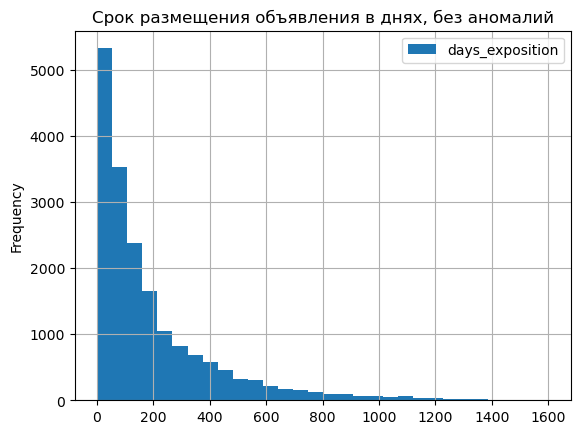

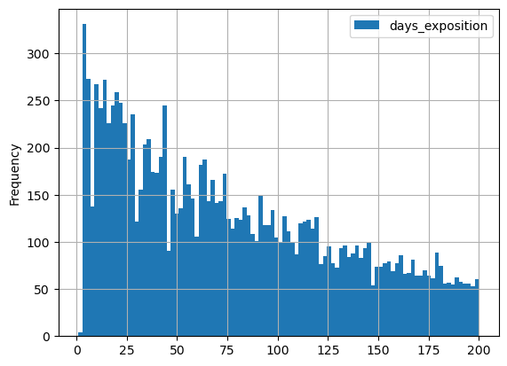

```python
#отфильтрую данные от аномалий и запишу их в новый датафрейм clear_data
clear_data = data.query('days_exposition != 45 and days_exposition != 30 and days_exposition != 60 and days_exposition != 90 and days_exposition != 7 and days_exposition != 0')

# строю гистограммы
clear_data.plot(y = 'days_exposition', kind = 'hist', bins = 30, grid = True, range = (1,1600),
          title='Срок размещения объявления в днях, без аномалий')
clear_data.plot(y = 'days_exposition', kind = 'hist', bins = 100, grid = True, range = (1,200))

#выведу общие сведения
clear_data['days_exposition'].describe()
```

```
(1.0, 1000.0)
```

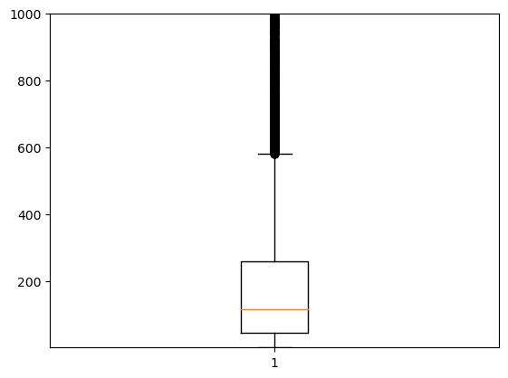

```python
#построю диаграмму размаха
plt.boxplot(clear_data['days_exposition'])
plt.ylim(1,1000)
```

**Вывод:** После удаления аномальных знчений изменились значения медианы и среднего - 114 и 195 соответственно, вместо 95 и 180. Теперь значения диаграмы размаха у нас изменились - от 1 до 600, вместо значений до фильтрации от 1 до 500. Следовательно нормальный срок продажи квартиры после обработки данных составляет от 1 до 600 дней (до обработки - от 1 до 500 дней). Необоснованно долгий срок продажи - от 600 дней и выше(до обработки - от 500 дней и выше). Быстрый срок продажи увеличился до 114 дней, против 95 дней до удаления аномальных значений.

Изучу, зависит ли цена квартиры от общей площади.

Для этого создам сводную таблицу в которой будут отображены средняя, количесвто и медиана цены в зависимости от общей площади квартиры.

```python
# создаю сводную таблицу
total_area_pivot = data.pivot_table(index = 'total_area', values = 'last_price', aggfunc = ['mean', 'count', 'median'])
# переименовываю столбцы
total_area_pivot.columns = ['mean', 'count', 'median']
# вывожу сводную таблицу на экран, отсортирую значения медианы по убыванию
display(total_area_pivot.sort_values('median', ascending = False))
```

| total_area | mean | count | median |
| --- | --- | --- | --- |
| 400.00 | 400500000.0 | 2 | 400500000.0 |
| 285.70 | 245000000.0 | 1 | 245000000.0 |
| 268.00 | 190870000.0 | 1 | 190870000.0 |
| 187.50 | 173869200.0 | 2 | 173869200.0 |
| 243.00 | 160000000.0 | 1 | 160000000.0 |
| ... | ... | ... | ... |
| 54.33 | 1300000.0 | 1 | 1300000.0 |
| 29.62 | 1300000.0 | 1 | 1300000.0 |
| 28.60 | 2034000.0 | 5 | 1060000.0 |
| 19.50 | 945750.0 | 1 | 945750.0 |
| 28.66 | 690000.0 | 1 | 690000.0 |

2123 rows × 3 columns

```
Корреляция между общей площадью и ценой равна 0.6202377746111629
```

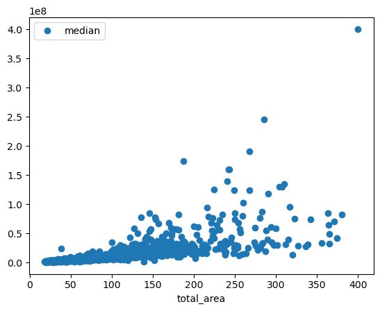

```python
# построю диаграмму рассеяния, по оси y возьму медиану
total_area_pivot.plot(y = 'median', style = 'o')
print('Корреляция между общей площадью и ценой равна', data['total_area'].corr(data['last_price']))
```

**Вывод:** Корреляция между общей площадью квартиры и ценой имеется, она равна 0,62. Из проведенного анализа я могу сделать вывод, что чем больше общая площадь квартиры, тем выше ее стоимость.

Далее проверю, зависит ли цена квартиры от жилой площади.

Для этого создам сводную таблицу в которой будут отображены средняя, количесвто и медиана цены в зависимости от жилой площади квартиры.

```python
# создаю сводную таблицу
living_area_pivot = data.pivot_table(index = 'living_area', values = 'last_price', aggfunc = ['mean', 'count', 'median'])
# переименовываю столбцы
living_area_pivot.columns = ['mean', 'count', 'median']
# вывожу сводную таблицу на экран, отсортирую значения медианы по убыванию
display(living_area_pivot.sort_values('median', ascending = False))
```

| living_area | mean | count | median |
| --- | --- | --- | --- |
| 182.80 | 245000000.0 | 1 | 245000000.0 |
| 179.00 | 148000000.0 | 1 | 148000000.0 |
| 187.90 | 130000000.0 | 1 | 130000000.0 |
| 163.50 | 125000000.0 | 1 | 125000000.0 |
| 107.03 | 124480000.0 | 1 | 124480000.0 |
| ... | ... | ... | ... |
| 16.31 | 1700000.0 | 1 | 1700000.0 |
| 18.11 | 1695000.0 | 2 | 1695000.0 |
| 12.81 | 1690715.0 | 1 | 1690715.0 |
| 10.94 | 1550000.0 | 1 | 1550000.0 |
| 20.97 | 990000.0 | 1 | 990000.0 |

1740 rows × 3 columns

```
Корреляция между жилой площадью и ценой равна 0.5383775045156487
```

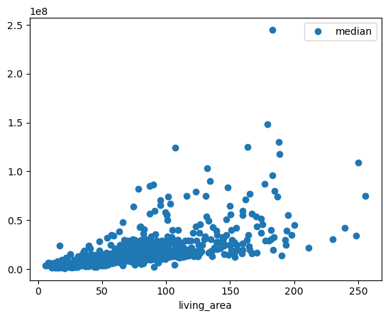

```python
# построю диаграмму рассеяния, по оси y возьму медиану
living_area_pivot.plot(y = 'median', style = 'o')
print('Корреляция между жилой площадью и ценой равна', data['living_area'].corr(data['last_price']))
```

**Вывод:** В данном случае вывод такой же, как и при изучении отношения общей площади к стоимости квартиры. Корреляция между жилой площадью квартиры и ценой имеется, она равна 0,53. Из проведенного анализа я могу сделать вывод, что чем больше жилая площадь квартиры, тем выше ее стоимость.

Далее изучу, зависит ли цена квартиры от площади кухни.

```python
# создаю сводную таблицу
kitchen_area_pivot = data.pivot_table(index = 'kitchen_area', values = 'last_price', aggfunc = ['mean', 'count', 'median'])
# переименовываю столбцы
kitchen_area_pivot.columns = ['mean', 'count', 'median']
# вывожу сводную таблицу на экран, отсортирую значения медианы по убыванию
display(kitchen_area_pivot.sort_values('median', ascending = False))
```

| kitchen_area | mean | count | median |
| --- | --- | --- | --- |
| 63.40 | 130000000.0 | 1 | 130000000.0 |
| 29.80 | 126000000.0 | 2 | 126000000.0 |
| 29.86 | 124480000.0 | 1 | 124480000.0 |
| 72.00 | 122000000.0 | 1 | 122000000.0 |
| 25.86 | 86738800.0 | 1 | 86738800.0 |
| ... | ... | ... | ... |
| 4.40 | 1800000.0 | 2 | 1800000.0 |
| 6.22 | 1720000.0 | 1 | 1720000.0 |
| 6.73 | 1718857.0 | 1 | 1718857.0 |
| 5.91 | 1300000.0 | 1 | 1300000.0 |
| 40.50 | 12190.0 | 1 | 12190.0 |

962 rows × 3 columns

```
Корреляция между площадью кухни и ценой равна 0.5255300409614311
```

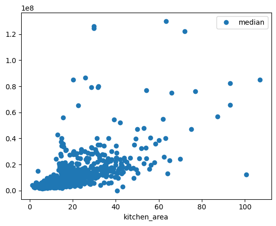

```python
# построю диаграмму рассеяния, по оси y возьму медиану
kitchen_area_pivot.plot(y = 'median', style = 'o')
print('Корреляция между площадью кухни и ценой равна', data['kitchen_area'].corr(data['last_price']))
```

**Вывод:** И снова похожая картина. Корреляция между площадью кухни и ценой имеется, она равна 0,52. Из проведенного анализа я могу сделать вывод, что чем больше площадь кухни, тем выше стоимость кватриры.

Узнаю, зависит ли цена квартиры от количества комнат в ней.

```python
# создаю сводную таблицу
rooms_pivot = data.pivot_table(index = 'rooms', values = 'last_price', aggfunc = ['mean', 'count', 'median'])
# переименовываю столбцы
rooms_pivot.columns = ['mean', 'count', 'median']
# вывожу сводную таблицу на экран, отсортирую значения медианы по убыванию
display(rooms_pivot.sort_values('median', ascending = False))
```

| rooms | mean | count | median |
| --- | --- | --- | --- |
| 7 | 4.098596e+07 | 51 | 22900000.0 |
| 6 | 2.735306e+07 | 99 | 18250000.0 |
| 5 | 2.140835e+07 | 319 | 13800000.0 |
| 4 | 1.319305e+07 | 1175 | 9000000.0 |
| 3 | 8.163724e+06 | 5804 | 6200000.0 |
| 2 | 5.590062e+06 | 7924 | 4768857.0 |
| 1 | 3.833069e+06 | 8009 | 3600000.0 |
| 0 | 3.347509e+06 | 188 | 2740000.0 |

```
Корреляция между количеством комнат и ценой равна 0.3507566178456733
```

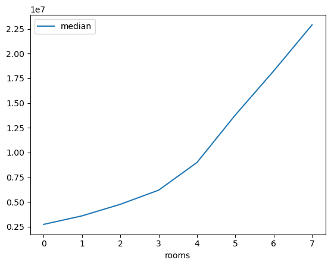

```python
# построю график, по оси y возьму медиану
rooms_pivot.plot(y = 'median')
print('Корреляция между количеством комнат и ценой равна', data['rooms'].corr(data['last_price']))
```

**Вывод:** Исходя из данных полученных в результате иследования я определила, что чем больше комнат тем выше стоимость квартиры.

Узнаю, зависит ли цена квартиры от этажа, на котором расположена квартира (первый, последний, другой).

Для этого создам сводную таблицу в которой будут отображены средняя, количесвто и медиана цены в зависимости от типа этажа.

```python
# создаю сводную таблицу
floor_type_pivot = data.pivot_table(index = 'floor_type', values = 'last_price', aggfunc = ['mean', 'count', 'median'])
# переименовываю столбцы
floor_type_pivot.columns = ['mean', 'count', 'median']
# вывожу сводную таблицу на экран, отсортирую значения медианы по убыванию
display(floor_type_pivot.sort_values('median', ascending = False))
```

| floor_type | mean | count | median |
| --- | --- | --- | --- |
| другой | 6.606370e+06 | 17298 | 4840000.0 |
| последний | 6.548905e+06 | 3302 | 4300000.0 |
| первый | 4.747072e+06 | 2895 | 3900000.0 |

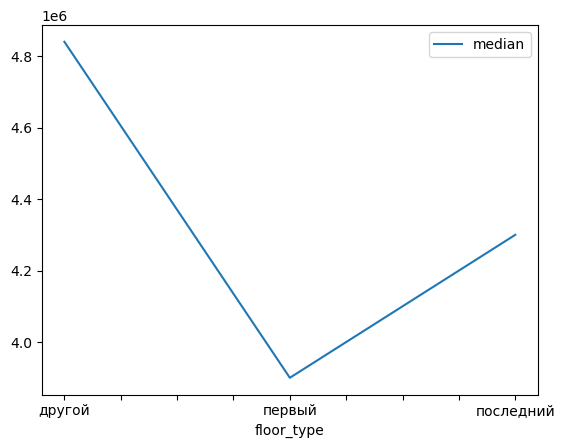

```python
# построю график, по оси y возьму медиану
floor_type_pivot.plot(y = 'median');
```

**Вывод:** Исходя из данных полученных в результате иследования я определила, что квартиры на первом этаже дешевле остальных. Квартиры на средних этажах (тип "другой") самые дорогие.

Узнаю, зависит ли цена квартиры от даты размещения объявления (день недели, месяц, год).

Для этого создам сводные таблицы по дням недели, месяцу и году размещения объявления в которых будут отображены средняя, количесвто и медиана цены в зависимости от даты.

Начну с дня недели

| weekday | mean | count | median |
| --- | --- | --- | --- |
| 1 | 6.306888e+06 | 4162 | 4700000.0 |
| 2 | 6.279348e+06 | 3946 | 4700000.0 |
| 0 | 6.334186e+06 | 3595 | 4650000.0 |
| 3 | 6.616983e+06 | 4268 | 4640000.0 |
| 4 | 6.326460e+06 | 3987 | 4575000.0 |
| 5 | 6.459474e+06 | 1925 | 4550000.0 |
| 6 | 6.190564e+06 | 1686 | 4550000.0 |

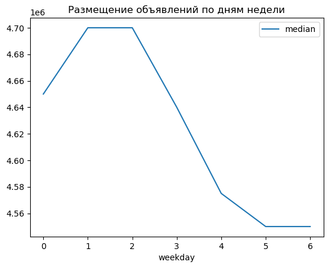

```python
# создаю сводную таблицу
weekday_pivot = data.pivot_table(index = 'weekday', values = 'last_price', aggfunc = ['mean', 'count', 'median'])
# переименовываю столбцы
weekday_pivot.columns = ['mean', 'count', 'median']
# вывожу сводную таблицу на экран, отсортирую значения медианы по убыванию
display(weekday_pivot.sort_values('median', ascending = False))
# построю график, по оси y возьму медиану
weekday_pivot.plot(y = 'median',
          title='Размещение объявлений по дням недели');
```

**Вывод:** Квартиры, объявления на которые были размещены во вторник и среду продаются по наибольшей стоимости. Далее идет по убывающей до конца недели. Дешевле всего квартиры, объявления на которые разместили в выходные дни.

Теперь возьмем месяц публикации

| month_publication | mean | count | median |
| --- | --- | --- | --- |
| 4 | 6.516728e+06 | 2370 | 4800000.0 |
| 9 | 6.763913e+06 | 1975 | 4700000.0 |
| 11 | 6.414120e+06 | 2362 | 4700000.0 |
| 12 | 6.526889e+06 | 1631 | 4700000.0 |
| 2 | 6.254384e+06 | 2623 | 4650000.0 |
| 3 | 6.252621e+06 | 2574 | 4650000.0 |
| 7 | 6.540885e+06 | 1681 | 4650000.0 |
| 1 | 6.366748e+06 | 1486 | 4600000.0 |
| 8 | 6.364701e+06 | 1737 | 4600000.0 |
| 10 | 5.985892e+06 | 2112 | 4550000.0 |
| 5 | 6.331975e+06 | 1268 | 4500000.0 |
| 6 | 6.202516e+06 | 1750 | 4400000.0 |

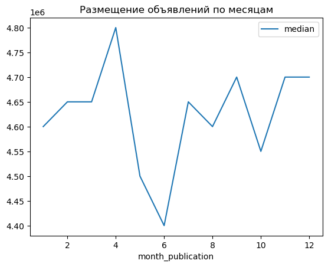

```python
# создаю сводную таблицу
month_publication_pivot = data.pivot_table(index = 'month_publication', values = 'last_price', aggfunc = ['mean', 'count', 'median'])
# переименовываю столбцы
month_publication_pivot.columns = ['mean', 'count', 'median']
# вывожу сводную таблицу на экран, отсортирую значения медианы по убыванию
display(month_publication_pivot.sort_values('median', ascending = False))
# построю график, по оси y возьму медиану
month_publication_pivot.plot(y = 'median',
          title='Размещение объявлений по месяцам');
```

Изучу год размещения объявления

| year_publication | mean | count | median |
| --- | --- | --- | --- |
| 2014 | 1.208714e+07 | 137 | 7700000.0 |
| 2015 | 8.197444e+06 | 1180 | 5300000.0 |
| 2019 | 6.614980e+06 | 2858 | 5042500.0 |
| 2018 | 5.912319e+06 | 8474 | 4555000.0 |
| 2016 | 6.599732e+06 | 2772 | 4500000.0 |
| 2017 | 6.321262e+06 | 8148 | 4500000.0 |

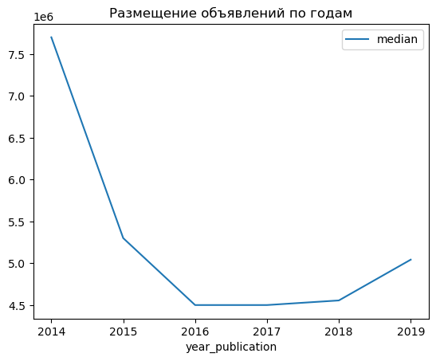

```python
# создаю сводную таблицу
year_publication_pivot = data.pivot_table(index = 'year_publication', values = 'last_price', aggfunc = ['mean', 'count', 'median'])
# переименовываю столбцы
year_publication_pivot.columns = ['mean', 'count', 'median']
# вывожу сводную таблицу на экран, отсортирую значения медианы по убыванию
display(year_publication_pivot.sort_values('median', ascending = False))
# построю график, по оси y возьму медиану
year_publication_pivot.plot(y = 'median',
          title='Размещение объявлений по годам');
```

```python
# создаю сводную таблицу, добавлю в нее общую площадь для сравнения
year_and_total_area_pivot = data.pivot_table(index = 'year_publication', values = ['last_price', 'total_area'], aggfunc = ['median'])
# вывожу на экран таблицу
display(year_and_total_area_pivot)
```

| year_publication | median last_price | median total_area |
| --- | --- | --- |
| 2014 | 7700000.0 | 76.26 |
| 2015 | 5300000.0 | 60.00 |
| 2016 | 4500000.0 | 53.00 |
| 2017 | 4500000.0 | 52.00 |
| 2018 | 4555000.0 | 50.50 |
| 2019 | 5042500.0 | 51.75 |

Посчитаю стоимость одного квадратного метра в 10 населённых пунктах с наибольшим числом объявлений.

Для этого создам сводную таблицу с количеством объявлений и средней ценой квадратного метра. Отсортирую таблицу по убыванию количества объявлений и оставлю только первые 10 строк. Далее найду максимальное и минимальное значение цены за квадратный метр из этих 10 населенных пунктов.

```python
# создаю сводную таблицу
locality_pivot_table = data.pivot_table(index = 'locality_name', values = 'price_metr', aggfunc=['count', 'median'])
# переименую столбцы
locality_pivot_table.columns = ['count', 'median']
# Отсотритую по убыванию кол-ва объявлений и оставлю первые 10 строк
locality_pivot_table = locality_pivot_table.sort_values('count', ascending = False).head(10)
# выведу сводную таблицу на экран
print(locality_pivot_table)
```

```
                   count     median
locality_name
Санкт-Петербург    15612  104687.50
поселок Мурино       555   85714.29
поселок Шушары       438   76747.97
Всеволожск           397   65789.47
Пушкин               369  100000.00
Колпино              337   74722.22
поселок Парголово    327   91642.86
Гатчина              307   67796.61
деревня Кудрово      299   91860.47
Выборг               235   58307.69
```

```python
# определю самую высокую стоимость
print(locality_pivot_table[locality_pivot_table['median']==locality_pivot_table['median'].max()])
```

```
                 count    median
locality_name
Санкт-Петербург  15612  104687.5
```

```python
# определю самую низкую стоимость
print(locality_pivot_table[locality_pivot_table['median']==locality_pivot_table['median'].min()])
```

```
               count    median
locality_name
Выборг           235  58307.69
```

**Вывод:** Из 10 населенных пунктов в которых выявленно наибольшее количество объявлений самая высокая стоимость квадратного метра в Санкт-Петербурге, а самая низкая в Выборге.

Ранее вы посчитали расстояние до центра в километрах. Теперь выделите квартиры в Санкт-Петербурге с помощью столбца locality_name и вычислите среднюю цену каждого километра. Опишите, как стоимость объектов зависит от расстояния до центра города — постройте график изменения средней цены для каждого километра от центра Петербурга.

Узнаю, как стоимость объектов недвижимости зависит от расстояния до центра города.

Для этого создам сводную таблицу в которой расчитаю кол-во объявлений и средную стоимость за квадратный метр в зависимости от удаленности от центра Санкт-Петербурга. Значения столбца `city_centers_nearest_in_km` равные 999999 в расчет брать не буду.

На основании сводной таблицы построю график.

| city_centers_nearest_in_km | count | mean |
| --- | --- | --- |
| 0 | 27 | 245833.530370 |
| 1 | 186 | 177354.526075 |
| 7 | 416 | 156243.745721 |
| 2 | 302 | 155973.502119 |
| 6 | 608 | 148459.434227 |
| 5 | 899 | 139067.402147 |
| 4 | 682 | 132952.615953 |
| 27 | 2 | 132115.710000 |
| 8 | 591 | 124229.711641 |
| 3 | 348 | 121179.151695 |
| 9 | 592 | 113116.623649 |
| 10 | 715 | 112906.300783 |
| 11 | 1172 | 108584.519027 |
| 13 | 1453 | 108131.550922 |
| 12 | 1599 | 107528.635353 |
| 15 | 1564 | 104292.879054 |
| 14 | 1276 | 104240.777908 |
| 16 | 1262 | 100530.764992 |
| 19 | 157 | 98652.735732 |
| 20 | 37 | 97440.054595 |
| 17 | 881 | 96601.845902 |
| 18 | 261 | 96362.263870 |
| 21 | 117 | 94469.584444 |
| 23 | 85 | 91828.517765 |
| 25 | 26 | 91531.371154 |
| 22 | 202 | 91330.425099 |
| 26 | 53 | 89285.877170 |
| 24 | 26 | 85736.904615 |
| 28 | 7 | 81161.914286 |
| 29 | 6 | 72953.365000 |

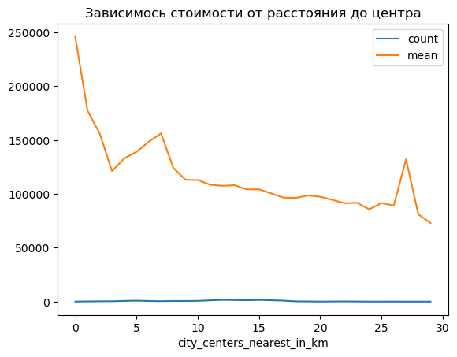

```python
# строю сводную таблицу
centr_spb_pivot =(data
                  .query('locality_name == "Санкт-Петербург" and city_centers_nearest_in_km !=999999')
                  .pivot_table(index = 'city_centers_nearest_in_km', values = 'price_metr', aggfunc = ['count','mean'])
                 )
# переименую столбцы
centr_spb_pivot.columns = ['count', 'mean']
# вывожу график
centr_spb_pivot.plot(title = 'Зависимось стоимости от расстояния до центра')
# выведу сводную таблицу
display(centr_spb_pivot.sort_values(by='mean', ascending=False))
```

**Вывод:** Проанализировав данные я определила, что в общем, чем ближе квартира к центру Санкт-Петербурга, тем выше стоимость квартиры, однако имеются отклонения, возможно они связаны с другими параметрами квартир, например с их состоянием, наличием или отсутсвием ремонта и т.д. К сожалению таких данных в выборке нет, можно дать предложения команде Яндекс Недвижимость о внесении дополнений в данные.

```python
print(data.isna().sum())
```

```
total_images                      0
last_price                        0
total_area                        0
first_day_exposition              0
rooms                             0
ceiling_height                 9167
floors_total                     77
living_area                    1880
floor                             0
is_apartment                      0
studio                            0
open_plan                         0
kitchen_area                   2237
balcony                           0
locality_name                    49
airports_nearest               5523
city_centers_nearest           5502
parks_around3000               5501
parks_nearest                 15557
ponds_around3000               5501
ponds_nearest                 14533
days_exposition                   0
locality_type                     0
price_metr                        0
weekday                           0
month_publication                 0
year_publication                  0
floor_type                       74
city_centers_nearest_in_km        0
dtype: int64
```

### Общий вывод

Ваша задача — провести исследовательский анализ данных, который поможет установить параметры, влияющие на цену объектов. Это позволит построить автоматизированную систему: она отследит аномалии и мошенническую деятельность

**Общий вывод:** В ходе работы проектом я провела исследовательский анализ данных, с целью установить параметры, влияющие на цену объектов недвижимости на примере архива объявлений о продаже квартир в Санкт-Петербурге и соседних населённых пунктах за несколько лет.

Среднестатистическая квартира на продажу выглядит так:

- общая площадь до 100 кв.м.;
- жилая площадь до 45 кв.м.;
- площадь кухни до 15 кв.м.;
- от 1 до 3х комнат;
- высота потолков около 2.5 м;
- расположена на средних этажах в 5 или 9 этажном здании на удалении от центра до 20 км и от парка около 1 км.

  Были выявлены следующие закономерности:
- стоимость квартиры зависит от ее размера, чем больше площадь, тем выше стоимость, это касается как общей площади, так и площади кухни и жилой площади;
- стоимость квартиры зависит от количества комнат в ней, чем больше комнат, тем больше стоимость;
- стоимость квартиры зависит от этажа на котором она находится, пырвый этаж продают дешевле всего;
- цена зависит от дня недели и месяца размещения объявления, так в объявлениях размещенных во вторник и среду квартиры дороже, а выходные дешевле, объявления размещенные в апреле имеют наибольшую цену;
- цена не зависит от года размещения объявления, в данном случае я увидела падение стоимости недвижимости после 2014 года и подъем после 2016 года, однако оно связано с уменьшением общей площади квартир выставляемых на продажу;
- стоимость квартиры зависит от населенного пункта в котором он находится, так стоимость квартир в Санкт-Петербугре выше, чем в остальных местах;
- стоимость зависит от удаленности от центра, чем ближе к центру, тем выше стоимость.

**В ходе выполнения данного проекта я провела следующую работу:**

- определила в каких столбцах имеются пропущенные данные и посчитати количество пропусков;
- построила гистограммы для всех числовых значений в таблице;
- построила корреляционную матрицу;
- изменила тип данных в столбцах `first_day_exposition`, `is_apartment` и `days_exposition`;
- заменила пропуски в столбцах `balcony`, `is_apartment` и `days_exposition` на 0;
- переименовала столбец `cityCenters_nearest`;
- удалила все явные и неявные дубликаты из столбца `locality_name`;
- добавила в таблицу новые столбцы `price_metr`. `weekday`, `month_publication`, `year_publication` и `city_centers_nearest_in_km`;
- провела категорирование квартир по типу этажа и записала полученные данные в новый столбец `floor_type`;
- изучила столбец `total_area`, построила гистограмму, получила общие сведения, удалила выбивающиеся значения;
- изучила столбец `living_area`, построила гистограмму, получила общие сведения, удалила выбивающиеся значения;
- изучила столбцы `kitchen_area`, `last_price`, `floor_type`, `city_centers_nearest`, `parks_nearest` постороила гистограмму, получила общие сведения;
- изучила столбец `rooms`, построила гистограмму, получила общие сведения, удалила выбивающиеся значения;
- изучила столбец `ceiling_height`, построила гистограмму, получила общие сведения, исправила аномальные значения, удалила выбивающиеся значения;
- изучила столбец `floors_total`, построила гистограмму, получила общие сведения, удалила выбивающиеся значения;
- изучила столбец `days_exposition`, построила гистограмму, получила общие сведения, построила диаграмму размаха, определила выбивающиеся значения и провела 2 исследования - по имеющимся данным и с удаленными выбивающимися значениями;
- с помощью сводных таблиц и диаграмм рассеяния определила зависимость цены от общей площади, жилой площади, площади кухни, количество комнат, типа этажа, на котором расположена квартира, даты размещения объявления;
- с помощью сводной таблицы определила стоимость квартиры в зависимости от населенного пункта;
- с помощью сводной таблицы определила зависимость стоимости квартир в Санкт-Петербурге от удаленности от центра.

**Рекомендации заказчику:**

1. Считаю целесообразным добавить информацию об объявлениях снятых с публикации в случае потери актуальности, чтобы понимать продана ли квартира или просто снято с публикации по сроку.
2. В данных имеется большое количество пропусков в информации загруженной на основе картографических данных, на это следует обратить внимание.
3. Считаю, что для полноты картины можно добавить в таблицу данные о состоянии объекта недвижимости.